# Spotify Machine Learning Analysis

#### Fall 2024 Data Science Project

#### Jiaoli Bowden, Anjali Paliyam, Jefferson Cheng, Akansha Dave, Amanda Tat

Contributions:

- Project idea: **Akansha** (pitched the idea of working with Spotify data), **Amanda** (found a dataset for Spotify)
- Dataset Curation and Preprocessing: **Amanda** (Did some simple preprocessing on the data as it was already pretty clean)
- Data Exploration and Summary Statistics: **Anjali** (worked on Hypothesis #3 which examines whether track genre is associated with the explicit content of the songs using the Chi Squared test) **Jefferson** (worked on Hypothesis #1 which attempts to find a correlation between song danceability and song popularity)
- ML Algorithm Design/Development: **Jefferson** (worked on ML design for Hypothesis #1 and trained a RandomForest model to predict song popularity based on 4 different features)
- ML Algorithm Training and Test Data Analytics: **Akansha** (worked on writing conclusions and explanations from test data analysis), **Amanda** (used the ML algorithms that Jefferson designed to analyze what predicts popularity in the pop genre)
- Visualization, Result Analysis, Conclusion: **Jefferson** (created graphs for Data exploration and ML Algorithm, wrote the conclusion/insights based on the ML analysis) **Akansha** (wrote out result analysis based on visualizations)
- Final Tutorial Report Creation: **Akansha** (formatted the final report and rewrote each section of text as a tutorial), **Jefferson** (created outline and working table of contents with links), **Anjali** (checked over order/layout of the sections in the final report)

# Introduction

Our topic is Spotify music and how the different aspects of the music influence its popularity. We are choosing this dataset because we listen to music and are interested in it. A large majority of people listen to music, and the most popular music streaming app is Spotify, so we thought that we could get the most accurate data from there. The main question that we are trying to answer with our analysis is whether or not a song's popularity is influenced by its musical aspects. By answering this question, we can find certain trends in popuarlity and we would be able to know exactly what aspects propel an artist's song to the top of Spotify.

1. Introduction
2. Data Curation
3. Data Exploration
4. Primary Analysis & Visualizations
5. Insights & Conclusions

# Data Curation

We can download this dataset as a csv to use in our Python project. Our Python project will require the use of several libraries, which we will import here. One vital library we will be using in this tutorial is Pandas, an open source data analysis tool. NumPy is fundamental for scientific computations.

```python
import pandas as pd
import statsmodels.api as sm
import numpy as np
import matplotlib.pyplot as plt
import seaborn as sns
from scipy import stats
from scipy.stats import f_oneway
from scipy.stats import chi2_contingency
from sklearn import linear_model
import warnings
warnings.filterwarnings('ignore')
```

Using Pandas, read the data from the csv file into a DataFrame, which is a data structure that allows us to easily manipulate and handle the data.

```python
df = pd.read_csv("hf://datasets/maharshipandya/spotify-tracks-dataset/dataset.csv")
df
```

|  | Unnamed: 0 | track_id | artists | album_name | track_name | popularity | duration_ms | explicit | danceability | energy | ... | loudness | mode | speechiness | acousticness | instrumentalness | liveness | valence | tempo | time_signature | track_genre |
| --- | --- | --- | --- | --- | --- | --- | --- | --- | --- | --- | --- | --- | --- | --- | --- | --- | --- | --- | --- | --- | --- |
| 0 | 0 | 5SuOikwiRyPMVoIQDJUgSV | Gen Hoshino | Comedy | Comedy | 73 | 230666 | False | 0.676 | 0.4610 | ... | -6.746 | 0 | 0.1430 | 0.0322 | 0.000001 | 0.3580 | 0.7150 | 87.917 | 4 | acoustic |
| 1 | 1 | 4qPNDBW1i3p13qLCt0Ki3A | Ben Woodward | Ghost (Acoustic) | Ghost - Acoustic | 55 | 149610 | False | 0.420 | 0.1660 | ... | -17.235 | 1 | 0.0763 | 0.9240 | 0.000006 | 0.1010 | 0.2670 | 77.489 | 4 | acoustic |
| 2 | 2 | 1iJBSr7s7jYXzM8EGcbK5b | Ingrid Michaelson;ZAYN | To Begin Again | To Begin Again | 57 | 210826 | False | 0.438 | 0.3590 | ... | -9.734 | 1 | 0.0557 | 0.2100 | 0.000000 | 0.1170 | 0.1200 | 76.332 | 4 | acoustic |
| 3 | 3 | 6lfxq3CG4xtTiEg7opyCyx | Kina Grannis | Crazy Rich Asians (Original Motion Picture Sou... | Can't Help Falling In Love | 71 | 201933 | False | 0.266 | 0.0596 | ... | -18.515 | 1 | 0.0363 | 0.9050 | 0.000071 | 0.1320 | 0.1430 | 181.740 | 3 | acoustic |
| 4 | 4 | 5vjLSffimiIP26QG5WcN2K | Chord Overstreet | Hold On | Hold On | 82 | 198853 | False | 0.618 | 0.4430 | ... | -9.681 | 1 | 0.0526 | 0.4690 | 0.000000 | 0.0829 | 0.1670 | 119.949 | 4 | acoustic |
| ... | ... | ... | ... | ... | ... | ... | ... | ... | ... | ... | ... | ... | ... | ... | ... | ... | ... | ... | ... | ... | ... |
| 113995 | 113995 | 2C3TZjDRiAzdyViavDJ217 | Rainy Lullaby | #mindfulness - Soft Rain for Mindful Meditatio... | Sleep My Little Boy | 21 | 384999 | False | 0.172 | 0.2350 | ... | -16.393 | 1 | 0.0422 | 0.6400 | 0.928000 | 0.0863 | 0.0339 | 125.995 | 5 | world-music |
| 113996 | 113996 | 1hIz5L4IB9hN3WRYPOCGPw | Rainy Lullaby | #mindfulness - Soft Rain for Mindful Meditatio... | Water Into Light | 22 | 385000 | False | 0.174 | 0.1170 | ... | -18.318 | 0 | 0.0401 | 0.9940 | 0.976000 | 0.1050 | 0.0350 | 85.239 | 4 | world-music |
| 113997 | 113997 | 6x8ZfSoqDjuNa5SVP5QjvX | Cesária Evora | Best Of | Miss Perfumado | 22 | 271466 | False | 0.629 | 0.3290 | ... | -10.895 | 0 | 0.0420 | 0.8670 | 0.000000 | 0.0839 | 0.7430 | 132.378 | 4 | world-music |
| 113998 | 113998 | 2e6sXL2bYv4bSz6VTdnfLs | Michael W. Smith | Change Your World | Friends | 41 | 283893 | False | 0.587 | 0.5060 | ... | -10.889 | 1 | 0.0297 | 0.3810 | 0.000000 | 0.2700 | 0.4130 | 135.960 | 4 | world-music |
| 113999 | 113999 | 2hETkH7cOfqmz3LqZDHZf5 | Cesária Evora | Miss Perfumado | Barbincor | 22 | 241826 | False | 0.526 | 0.4870 | ... | -10.204 | 0 | 0.0725 | 0.6810 | 0.000000 | 0.0893 | 0.7080 | 79.198 | 4 | world-music |

114000 rows × 21 columns

Now that we have a DataFrame, let's take a look at its characteristics. Print its columns.

```python
df = df.rename(columns={'Unnamed: 0':"index"})
df.set_index("index", inplace=True)
df.columns
```

```
Index(['track_id', 'artists', 'album_name', 'track_name', 'popularity',
       'duration_ms', 'explicit', 'danceability', 'energy', 'key', 'loudness',
       'mode', 'speechiness', 'acousticness', 'instrumentalness', 'liveness',
       'valence', 'tempo', 'time_signature', 'track_genre'],
      dtype='object')
```

It's important to identify any NaN values in our dataset. Loop through the columns in the DataFrame and print which specific columns, if any, have NaN values.

```python
for c in df.columns:
  if df[c].isna().any():
      print("Column", c, "contains", df[c].isna().sum(), "NaN values")
```

```
Column artists contains 1 NaN values
Column album_name contains 1 NaN values
Column track_name contains 1 NaN values
```

Since we found a very small amount of NaN values (< 1%), we'll just delete those rows.

```python
df.dropna()
```

| index | track_id | artists | album_name | track_name | popularity | duration_ms | explicit | danceability | energy | key | loudness | mode | speechiness | acousticness | instrumentalness | liveness | valence | tempo | time_signature | track_genre |
| --- | --- | --- | --- | --- | --- | --- | --- | --- | --- | --- | --- | --- | --- | --- | --- | --- | --- | --- | --- | --- |
| 0 | 5SuOikwiRyPMVoIQDJUgSV | Gen Hoshino | Comedy | Comedy | 73 | 230666 | False | 0.676 | 0.4610 | 1 | -6.746 | 0 | 0.1430 | 0.0322 | 0.000001 | 0.3580 | 0.7150 | 87.917 | 4 | acoustic |
| 1 | 4qPNDBW1i3p13qLCt0Ki3A | Ben Woodward | Ghost (Acoustic) | Ghost - Acoustic | 55 | 149610 | False | 0.420 | 0.1660 | 1 | -17.235 | 1 | 0.0763 | 0.9240 | 0.000006 | 0.1010 | 0.2670 | 77.489 | 4 | acoustic |
| 2 | 1iJBSr7s7jYXzM8EGcbK5b | Ingrid Michaelson;ZAYN | To Begin Again | To Begin Again | 57 | 210826 | False | 0.438 | 0.3590 | 0 | -9.734 | 1 | 0.0557 | 0.2100 | 0.000000 | 0.1170 | 0.1200 | 76.332 | 4 | acoustic |
| 3 | 6lfxq3CG4xtTiEg7opyCyx | Kina Grannis | Crazy Rich Asians (Original Motion Picture Sou... | Can't Help Falling In Love | 71 | 201933 | False | 0.266 | 0.0596 | 0 | -18.515 | 1 | 0.0363 | 0.9050 | 0.000071 | 0.1320 | 0.1430 | 181.740 | 3 | acoustic |
| 4 | 5vjLSffimiIP26QG5WcN2K | Chord Overstreet | Hold On | Hold On | 82 | 198853 | False | 0.618 | 0.4430 | 2 | -9.681 | 1 | 0.0526 | 0.4690 | 0.000000 | 0.0829 | 0.1670 | 119.949 | 4 | acoustic |
| ... | ... | ... | ... | ... | ... | ... | ... | ... | ... | ... | ... | ... | ... | ... | ... | ... | ... | ... | ... | ... |
| 113995 | 2C3TZjDRiAzdyViavDJ217 | Rainy Lullaby | #mindfulness - Soft Rain for Mindful Meditatio... | Sleep My Little Boy | 21 | 384999 | False | 0.172 | 0.2350 | 5 | -16.393 | 1 | 0.0422 | 0.6400 | 0.928000 | 0.0863 | 0.0339 | 125.995 | 5 | world-music |
| 113996 | 1hIz5L4IB9hN3WRYPOCGPw | Rainy Lullaby | #mindfulness - Soft Rain for Mindful Meditatio... | Water Into Light | 22 | 385000 | False | 0.174 | 0.1170 | 0 | -18.318 | 0 | 0.0401 | 0.9940 | 0.976000 | 0.1050 | 0.0350 | 85.239 | 4 | world-music |
| 113997 | 6x8ZfSoqDjuNa5SVP5QjvX | Cesária Evora | Best Of | Miss Perfumado | 22 | 271466 | False | 0.629 | 0.3290 | 0 | -10.895 | 0 | 0.0420 | 0.8670 | 0.000000 | 0.0839 | 0.7430 | 132.378 | 4 | world-music |
| 113998 | 2e6sXL2bYv4bSz6VTdnfLs | Michael W. Smith | Change Your World | Friends | 41 | 283893 | False | 0.587 | 0.5060 | 7 | -10.889 | 1 | 0.0297 | 0.3810 | 0.000000 | 0.2700 | 0.4130 | 135.960 | 4 | world-music |
| 113999 | 2hETkH7cOfqmz3LqZDHZf5 | Cesária Evora | Miss Perfumado | Barbincor | 22 | 241826 | False | 0.526 | 0.4870 | 1 | -10.204 | 0 | 0.0725 | 0.6810 | 0.000000 | 0.0893 | 0.7080 | 79.198 | 4 | world-music |

113999 rows × 20 columns

All of the datatypes of each column already make sense so there is no change needed (i.e. words are strings, numbers are ints, decimals are floats, and True/False is bool).

# Exploratory Data Analysis

## Main Characteristics of the Dataset:

Here we have a small breakdown of the different categories and their mean, standard deviation, and other useful statistics.

```python
print("Main Characteristics of the Dataset:")
print(f"Number of Features: {df.shape[1]}")
print(f"Number of Entries: {df.shape[0]}")
print("Feature Information:")
with pd.option_context('display.max_columns', 14):
  print(df.describe(include=[np.number]))
```

```
Main Characteristics of the Dataset:
Number of Features: 20
Number of Entries: 114000
Feature Information:
          popularity   duration_ms   danceability         energy  \
count  114000.000000  1.140000e+05  114000.000000  114000.000000
mean       33.238535  2.280292e+05       0.566800       0.641383
std        22.305078  1.072977e+05       0.173542       0.251529
min         0.000000  0.000000e+00       0.000000       0.000000
25%        17.000000  1.740660e+05       0.456000       0.472000
50%        35.000000  2.129060e+05       0.580000       0.685000
75%        50.000000  2.615060e+05       0.695000       0.854000
max       100.000000  5.237295e+06       0.985000       1.000000

                 key       loudness           mode    speechiness  \
count  114000.000000  114000.000000  114000.000000  114000.000000
mean        5.309140      -8.258960       0.637553       0.084652
std         3.559987       5.029337       0.480709       0.105732
min         0.000000     -49.531000       0.000000       0.000000
25%         2.000000     -10.013000       0.000000       0.035900
50%         5.000000      -7.004000       1.000000       0.048900
75%         8.000000      -5.003000       1.000000       0.084500
max        11.000000       4.532000       1.000000       0.965000

        acousticness  instrumentalness       liveness        valence  \
count  114000.000000     114000.000000  114000.000000  114000.000000
mean        0.314910          0.156050       0.213553       0.474068
std         0.332523          0.309555       0.190378       0.259261
min         0.000000          0.000000       0.000000       0.000000
25%         0.016900          0.000000       0.098000       0.260000
50%         0.169000          0.000042       0.132000       0.464000
75%         0.598000          0.049000       0.273000       0.683000
max         0.996000          1.000000       1.000000       0.995000

               tempo  time_signature
count  114000.000000   114000.000000
mean      122.147837        3.904035
std        29.978197        0.432621
min         0.000000        0.000000
25%        99.218750        4.000000
50%       122.017000        4.000000
75%       140.071000        4.000000
max       243.372000        5.000000
```

We use this function to detect any outliers in the dataset

```python
def detect_outliers_iqr(df, column):
  Q1 = df[column].quantile(0.25)
  Q3 = df[column].quantile(0.75)
  IQR = Q3 - Q1
  lower_bound = Q1 - 1.5 * IQR
  upper_bound = Q3 + 1.5 * IQR
  return df[(df[column] < lower_bound) | (df[column] > upper_bound)]
```

Previously when exploring our data, we saw that some songs appear in the data twice because they have multiple genres associated with it, so we can make a different dataframe with unique songs if we aren't looking at any specific genres.

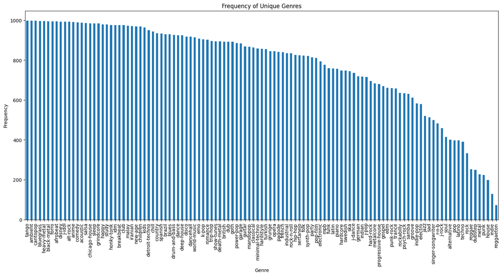

```python
df_unique = df.drop_duplicates(subset=["track_name", "album_name"])
df_unique.value_counts("track_genre").plot(kind="bar")
plt.gcf().set_size_inches(18, 8)
plt.title("Frequency of Unique Genres")
plt.xlabel("Genre")
plt.ylabel("Frequency")
plt.show()
```

Here is a histogram showing the overall distribution of the popularity of the spotify songs

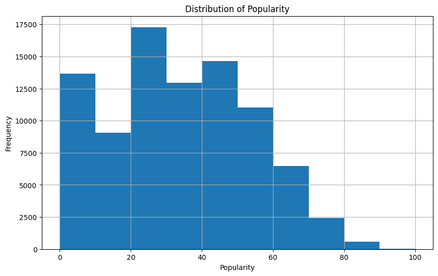

```python
df_unique.hist(column="popularity", bins=10, figsize=(10, 6))
plt.title('Distribution of Popularity')
plt.xlabel('Popularity')
plt.ylabel('Frequency')
plt.show()
```

Knowing the track genres and popularities, we can create a graph showing the popularities of every single genre to get a feel of what music genres are the most popular on Spotify.

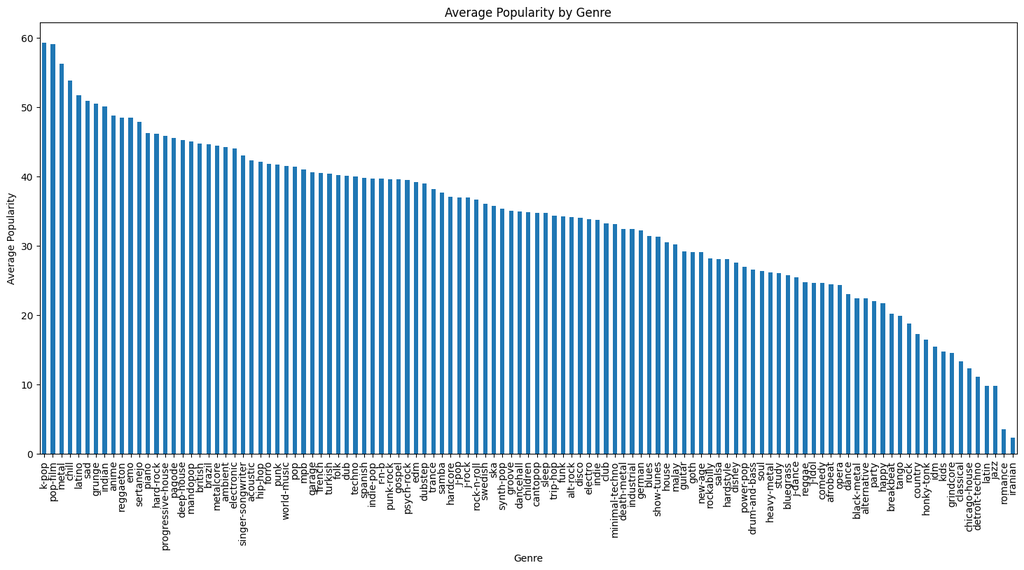

```python
# Create a graph showing the average popularity for each track genre
genre_popularity = df_unique.groupby('track_genre')['popularity'].mean()
genre_popularity.sort_values(ascending=False).plot(kind='bar', figsize=(18, 8))
plt.title('Average Popularity by Genre')
plt.xlabel('Genre')
plt.ylabel('Average Popularity')
plt.show()
```

Here we have a graph showing the popularity distribution of 'pop' songs specifically.

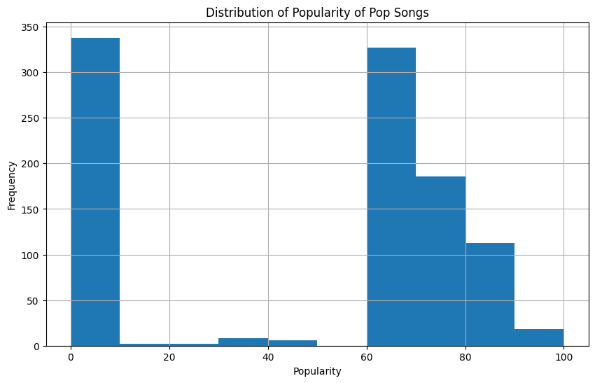

```python
pop_df = df[df['track_genre'] == 'pop']
pop_df.hist(column="popularity", bins=10, figsize=(10, 6))
plt.title('Distribution of Popularity of Pop Songs')
plt.xlabel('Popularity')
plt.ylabel('Frequency')
plt.show()
```

Here, we can see that a bit more than a third of all pop songs in the dataset have less than 60 popularity score.

# Primary Analysis & Visualizations

In order to develop a predictive model of our data, we will perform a variety of modeling techniques. We will begin with 3 hypothesis tests.

### **Hypothesis Test #1**

If a song is more danceable, then it will be more likely that the song will be popular, since people will be more motivated to dance to it, therefore increasing its popularity. \

H0: Danceability has no affect on the song's popularity \ Ha: Danceability has a positive affect on the song's popularity \ Confidence Level: 95%, so α = 0.05 \

```python
df_unique['popularity_normalized'] = (df_unique['popularity'] - df_unique['popularity'].mean()) / df_unique['popularity'].std()
df_unique['danceability_normalized'] = (df_unique['danceability'] - df_unique['danceability'].mean()) / df_unique['danceability'].std()
t_stat, p_value = stats.ttest_rel(df_unique['danceability_normalized'], df_unique['popularity_normalized'])
print("t-statistic:", t_stat)
print("p-value:", p_value)

plt.figure(figsize=(12, 6))
sns.scatterplot(x='danceability', y='popularity', data=df_unique)
plt.title('Scatter Plot of the relationship between danceability and popularity')
plt.xlabel('Danceability')
plt.ylabel('Popularity')
plt.grid(True)
plt.show()
```

[output not shown]

Danceability and Popularity Hypothesis Testing conclusion: \ Since our p-value = 0.9999999999998874, which is very close to 1 and > 0.05, that means we do not have enough evidence to reject the null hypothesis, so we fail to reject the null hypothesis. This means that danceability likely has no affect on popularity, as we failed to reject the null hypothesis.

```
Number of outliers in popularity: 21
```

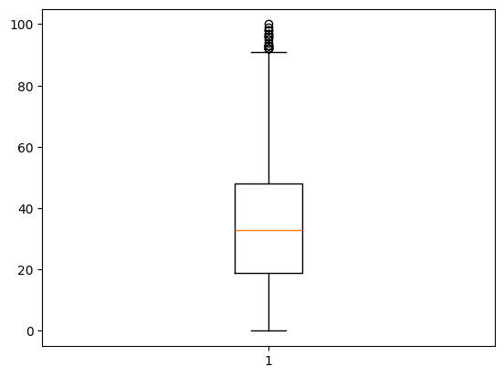

```python
popularity_outliers = detect_outliers_iqr(df_unique, "popularity")
print("Number of outliers in popularity:", len(popularity_outliers))

plt.boxplot(df_unique["popularity"])
plt.show()
```

```
Outliers in danceability: 436
```

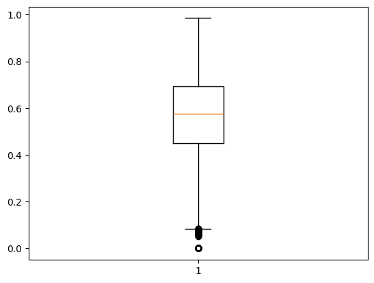

```python
danceability_outliers = detect_outliers_iqr(df_unique, "danceability")
print("Outliers in danceability:", len(danceability_outliers["track_name"]))
plt.boxplot(df_unique["danceability"])
plt.show()
```

The amount of outliers in proportion to the data is not significant and the value of the outliers is not that far from the rest of the data. Furthermore, because we are testing for if danceability affects popularity, every point counts, even outliers, so they were not removed for this test.

We can use linear regression for this hypothesis test to see if we can get a good line of fit to predict popularity based on danceability.

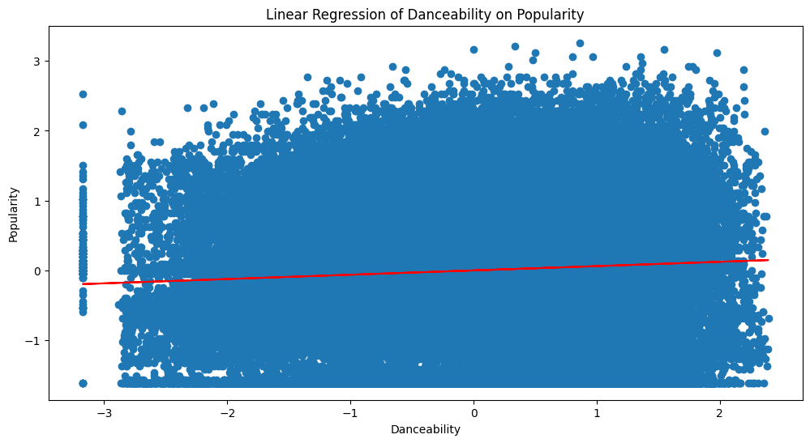

```python
lobf = linear_model.LinearRegression()
x = df_unique['danceability_normalized'].values.reshape(-1, 1)
y = df_unique['popularity_normalized'].values.reshape(-1, 1)
lobf.fit(x, y)
predicted = lobf.predict(x)
plt.figure(figsize=(12, 6))
plt.scatter(x, y)
plt.plot(x, predicted, color='red')
plt.title('Linear Regression of Danceability on Popularity')
plt.xlabel('Danceability')
plt.ylabel('Popularity')
plt.show()
```

We can see from the linear regression line, that since the line is somewhat flat, it would not be a good estimate, which lines up with our hypothesis testing that danceability does not affect popularity.

We can confirm how good the regression line is by taking the R^2 value of the line.

```python
r2 = lobf.score(x, y)
print("R^2 value:", r2)
```

```
R^2 value: 0.0038082659120847184
```

Since the R^2 value is extremely close to 0, that means that there is no linear relationship between danceability and popularity.

We can train some models to do a Logistic Regression to how well the other columns perform in helping us predict popularity.

```python
from sklearn.model_selection import train_test_split
from sklearn.metrics import accuracy_score, classification_report
from sklearn.tree import DecisionTreeClassifier
from sklearn.neighbors import KNeighborsClassifier
from sklearn.linear_model import LogisticRegression
from sklearn.ensemble import RandomForestClassifier
from sklearn.preprocessing import StandardScaler

features = ['loudness', 'valence', 'acousticness', 'danceability']
df_unique['popularity_binary'] = df_unique['popularity'] > 50
x = df_unique[features]
y = df_unique['popularity_binary']

seed = 42
test_size=0.2
X_train, X_test, y_train, y_test = train_test_split(x, y, test_size=test_size, random_state=seed)
scaler = StandardScaler()
X_train_scaled = scaler.fit_transform(X_train)
X_test_scaled = scaler.transform(X_test)

models = {
    'LogisticRegression': LogisticRegression(),
    'KNN': KNeighborsClassifier(),
    'DecisionTree': DecisionTreeClassifier(),
    'RandomForest': RandomForestClassifier()
}
for model_name, model in models.items():
    np.random.seed(seed)
    model.fit(X_train_scaled, y_train)


for model_name, model in models.items():
    np.random.seed(seed)
    y_pred = model.predict(X_test_scaled)
    accuracy = accuracy_score(y_test, y_pred)
    print(f"Accuracy of {model_name}: {accuracy:.2f}")
    print(classification_report(y_test, y_pred))
```

```
Accuracy of LogisticRegression: 0.78
              precision    recall  f1-score   support

       False       0.78      1.00      0.87     13710
        True       0.00      0.00      0.00      3927

    accuracy                           0.78     17637
   macro avg       0.39      0.50      0.44     17637
weighted avg       0.60      0.78      0.68     17637

Accuracy of KNN: 0.74
              precision    recall  f1-score   support

       False       0.79      0.91      0.85     13710
        True       0.30      0.13      0.18      3927

    accuracy                           0.74     17637
   macro avg       0.55      0.52      0.51     17637
weighted avg       0.68      0.74      0.70     17637

Accuracy of DecisionTree: 0.68
              precision    recall  f1-score   support

       False       0.80      0.78      0.79     13710
        True       0.28      0.30      0.29      3927

    accuracy                           0.68     17637
   macro avg       0.54      0.54      0.54     17637
weighted avg       0.68      0.68      0.68     17637

Accuracy of RandomForest: 0.77
              precision    recall  f1-score   support

       False       0.79      0.97      0.87     13710
        True       0.39      0.08      0.13      3927

    accuracy                           0.77     17637
   macro avg       0.59      0.52      0.50     17637
weighted avg       0.70      0.77      0.70     17637
```

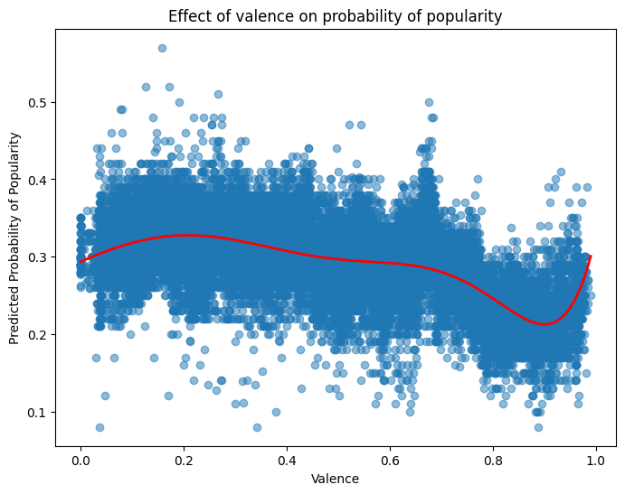

```python
y_probs = model.predict_proba(X_test)[:, 1]

# Scatterplot
plt.figure(figsize=(8, 6))
plt.scatter(X_test['valence'], y_probs, alpha=0.5)
plt.xlabel('Valence')
plt.ylabel('Predicted Probability of Popularity')
plt.title('Effect of valence on probability of popularity')

degree = 7
coefficients = np.polyfit(X_test['valence'], y_probs, degree)
poly_function = np.poly1d(coefficients)
X_val_sorted = np.sort(X_test['valence'])
y_probs_poly = poly_function(X_val_sorted)
plt.plot(X_val_sorted, y_probs_poly, color='red', linewidth=2)

plt.show()
```

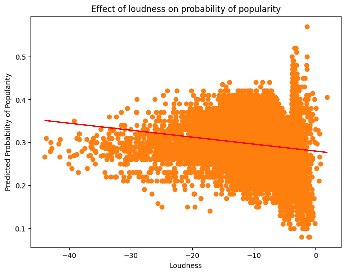

```python
plt.figure(figsize=(8, 6))
plt.scatter(X_test['loudness'], y_probs, alpha=0.5)
plt.xlabel('Loudness')
plt.ylabel('Predicted Probability of Popularity')
plt.title('Effect of loudness on probability of popularity')

X_val_sorted = np.sort(X_test['loudness'])
y_probs_sorted = np.sort(y_probs)
x = X_test['loudness']
y = y_probs
lobf = linear_model.LinearRegression()
x = x.values.reshape(-1, 1)
lobf.fit(x, y)
predicted = lobf.predict(x)
plt.scatter(x, y)
plt.plot(x, predicted, color='red')

plt.show()
```

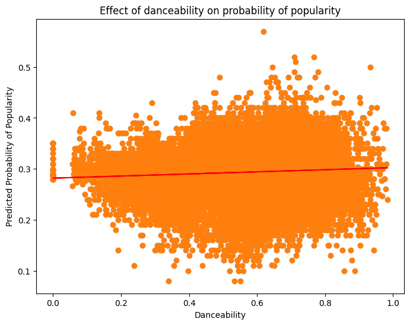

```python
plt.figure(figsize=(8, 6))
plt.scatter(X_test['danceability'], y_probs, alpha=0.5)
plt.xlabel('Danceability')
plt.ylabel('Predicted Probability of Popularity')
plt.title('Effect of danceability on probability of popularity')

X_val_sorted = np.sort(X_test['danceability'])
y_probs_sorted = np.sort(y_probs)
x = X_test['danceability']
y = y_probs
lobf = linear_model.LinearRegression()
x = x.values.reshape(-1, 1)
lobf.fit(x, y)
predicted = lobf.predict(x)
plt.scatter(x, y)
plt.plot(x, predicted, color='red')

plt.show()
```

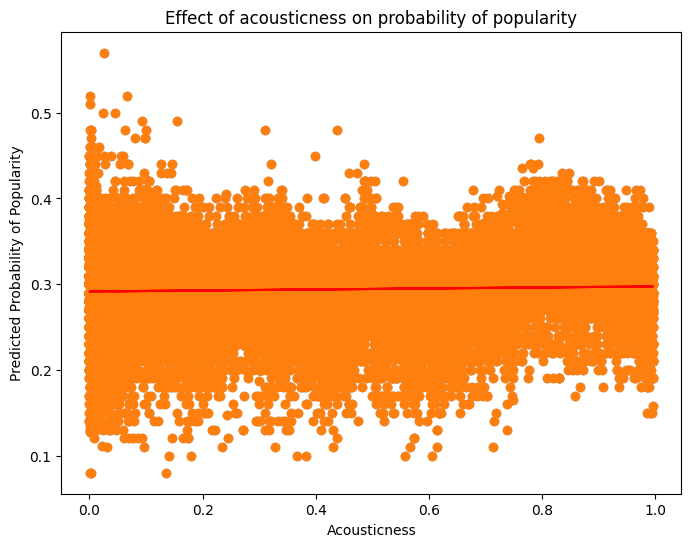

```python
plt.figure(figsize=(8, 6))
plt.scatter(X_test['acousticness'], y_probs, alpha=0.5)
plt.xlabel('Acousticness')
plt.ylabel('Predicted Probability of Popularity')
plt.title('Effect of acousticness on probability of popularity')

X_val_sorted = np.sort(X_test['acousticness'])
y_probs_sorted = np.sort(y_probs)
x = X_test['acousticness']
y = y_probs
lobf = linear_model.LinearRegression()
x = x.values.reshape(-1, 1)
lobf.fit(x, y)
predicted = lobf.predict(x)
plt.scatter(x, y)
plt.plot(x, predicted, color='red')

plt.show()
```

Looking at the graphs for predicted popularity with loudness, valence, dancability, and acousticness, it seems that none would be good predictors. However, these graphs mix every genre of music in the database and it is likely that people who listen to certain genres of music perfer different features in the songs. Let's do the same analaysis on the pop genre!

First, retrain the models to only focus on the pop genre.

```python
features = ['loudness', 'valence', 'acousticness', 'danceability']
df['popularity_binary'] = df['popularity'] > 50
x = df[df['track_genre'] == 'pop'][features]
y = df[df['track_genre'] == 'pop']['popularity_binary']

seed = 42
test_size=0.2
X_train, X_test, y_train, y_test = train_test_split(x, y, test_size=test_size, random_state=seed)
scaler = StandardScaler()
X_train_scaled = scaler.fit_transform(X_train)
X_test_scaled = scaler.transform(X_test)

models = {
    'LogisticRegression': LogisticRegression(),
    'KNN': KNeighborsClassifier(),
    'DecisionTree': DecisionTreeClassifier(),
    'RandomForest': RandomForestClassifier()
}
for model_name, model in models.items():
    np.random.seed(seed)
    model.fit(X_train_scaled, y_train)


for model_name, model in models.items():
    np.random.seed(seed)
    y_pred = model.predict(X_test_scaled)
    accuracy = accuracy_score(y_test, y_pred)
    print(f"Accuracy of {model_name}: {accuracy:.2f}")
    print(classification_report(y_test, y_pred))
```

```
Accuracy of LogisticRegression: 0.61
              precision    recall  f1-score   support

       False       0.83      0.06      0.11        81
        True       0.61      0.99      0.75       119

    accuracy                           0.61       200
   macro avg       0.72      0.53      0.43       200
weighted avg       0.70      0.61      0.50       200

Accuracy of KNN: 0.74
              precision    recall  f1-score   support

       False       0.68      0.69      0.69        81
        True       0.79      0.78      0.78       119

    accuracy                           0.74       200
   macro avg       0.74      0.74      0.74       200
weighted avg       0.75      0.74      0.75       200

Accuracy of DecisionTree: 0.76
              precision    recall  f1-score   support

       False       0.69      0.74      0.71        81
        True       0.81      0.77      0.79       119

    accuracy                           0.76       200
   macro avg       0.75      0.76      0.75       200
weighted avg       0.76      0.76      0.76       200

Accuracy of RandomForest: 0.84
              precision    recall  f1-score   support

       False       0.87      0.72      0.78        81
        True       0.83      0.92      0.87       119

    accuracy                           0.84       200
   macro avg       0.85      0.82      0.83       200
weighted avg       0.84      0.84      0.84       200
```

Now, let's analyze model **valence** against popularity.

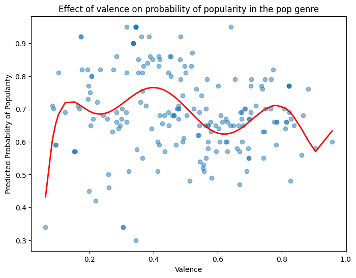

```python
y_probs = model.predict_proba(X_test)[:, 1]

# Scatterplot
plt.figure(figsize=(8, 6))
plt.scatter(X_test['valence'], y_probs, alpha=0.5)
plt.xlabel('Valence')
plt.ylabel('Predicted Probability of Popularity')
plt.title('Effect of valence on probability of popularity in the pop genre')

degree = 7
coefficients = np.polyfit(X_test['valence'], y_probs, degree)
poly_function = np.poly1d(coefficients)
X_val_sorted = np.sort(X_test['valence'])
y_probs_poly = poly_function(X_val_sorted)
plt.plot(X_val_sorted, y_probs_poly, color='red', linewidth=2)

plt.show()
```

Next, check for model **loudness** against popularity.

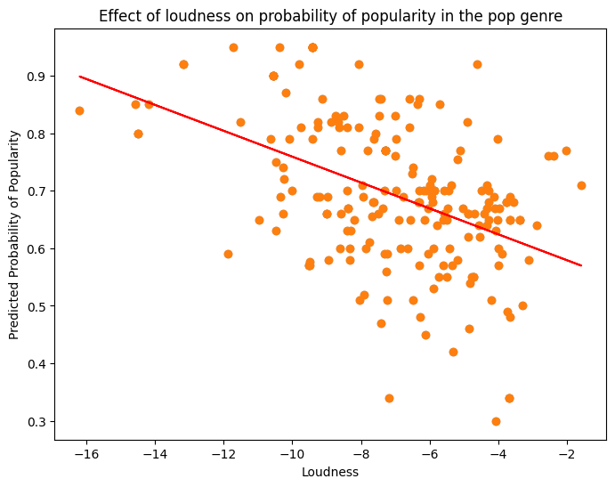

```python
plt.figure(figsize=(8, 6))
plt.scatter(X_test['loudness'], y_probs, alpha=0.5)
plt.xlabel('Loudness')
plt.ylabel('Predicted Probability of Popularity')
plt.title('Effect of loudness on probability of popularity in the pop genre')

X_val_sorted = np.sort(X_test['loudness'])
y_probs_sorted = np.sort(y_probs)
x = X_test['loudness']
y = y_probs
lobf = linear_model.LinearRegression()
x = x.values.reshape(-1, 1)
lobf.fit(x, y)
predicted = lobf.predict(x)
plt.scatter(x, y)
plt.plot(x, predicted, color='red')

plt.show()
```

Depict the model **danceability** against popularity.

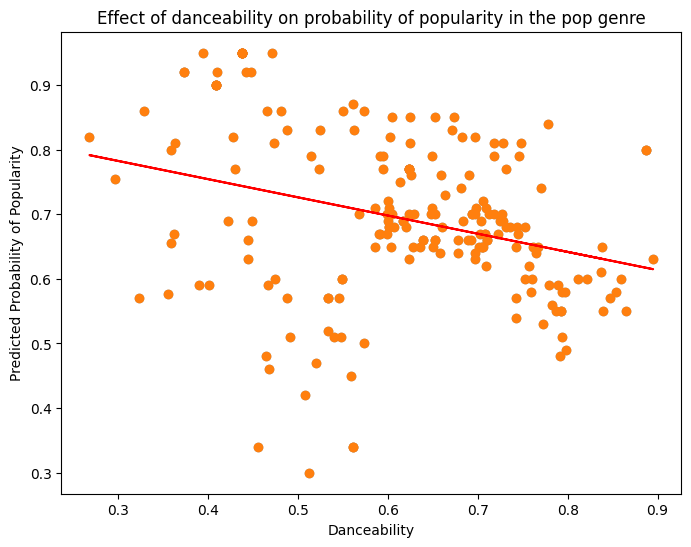

```python
plt.figure(figsize=(8, 6))
plt.scatter(X_test['danceability'], y_probs, alpha=0.5)
plt.xlabel('Danceability')
plt.ylabel('Predicted Probability of Popularity')
plt.title('Effect of danceability on probability of popularity in the pop genre')

X_val_sorted = np.sort(X_test['danceability'])
y_probs_sorted = np.sort(y_probs)
x = X_test['danceability']
y = y_probs
lobf = linear_model.LinearRegression()
x = x.values.reshape(-1, 1)
lobf.fit(x, y)
predicted = lobf.predict(x)
plt.scatter(x, y)
plt.plot(x, predicted, color='red')

plt.show()
```

Lastly, find model **acousticness** against popularity.

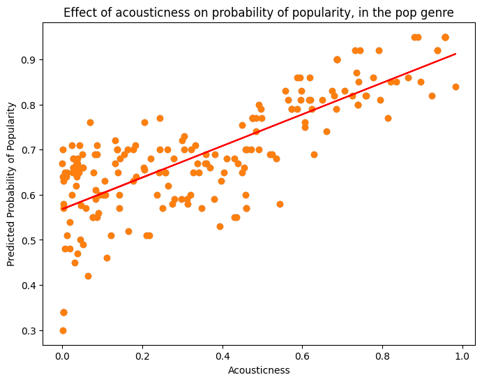

```python
plt.figure(figsize=(8, 6))
plt.scatter(X_test['acousticness'], y_probs, alpha=0.5)
plt.xlabel('Acousticness')
plt.ylabel('Predicted Probability of Popularity')
plt.title('Effect of acousticness on probability of popularity, in the pop genre')

X_val_sorted = np.sort(X_test['acousticness'])
y_probs_sorted = np.sort(y_probs)
x = X_test['acousticness']
y = y_probs
lobf = linear_model.LinearRegression()
x = x.values.reshape(-1, 1)
lobf.fit(x, y)
predicted = lobf.predict(x)
plt.scatter(x, y)
plt.plot(x, predicted, color='red')

plt.show()
```

Looking at the graphs now, we can identify some trends that we can take away from them.

1. For valence, there seems to be no clear trend as the model gives no clear progression. There are also a good amount of data points that are far away from the model, making it not a strong predictor.
2. For loudness, the model shows that the louder the song is, the less popular the song is predicted to be.
3. For danceability, the model predicts that the more dancability it has, the less popular the song is. However, the popularity decrease from more danceability seems to be less than the popularity decrease from being louder.
4. For acousticness, the model predicts a trend of higher acousticness leads to higher popularity.

### **Hypothesis Test #2**:

Pop, indie-pop, and k-pop are all different subcategories of pop music! Since they are all different aspects of pop, is there a signficant difference between the three? We can look at the valence of the different genres!

H0: There is no difference in valence between the different genres

Ha: Some genres have more valence than others.

Confidence Level: 95%, so α = 0.05

```python
pop_df = df[df['track_genre'] == 'pop']['valence']
indie_pop_df = df[df['track_genre'] == 'indie-pop']['valence']
k_pop_df = df[df['track_genre'] == 'k-pop']['valence']
```

```python
_, p = f_oneway(pop_df, indie_pop_df, k_pop_df)
p
```

```
2.4224182828811618e-23
```

We get a p-value of $2.4*10^{-23}$, which is extremely significant because p is very much lower than α = 0.05. This means that there is likely a difference between the valences of the different genres. We'll explore where they are in the box plots below.

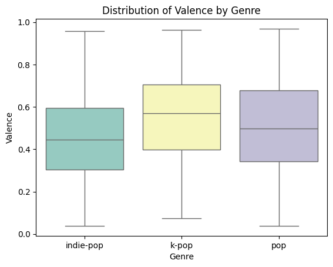

```python
genres = ['pop', 'indie-pop', 'k-pop']
df_selected = df[df['track_genre'].isin(genres)]

sns.boxplot(x='track_genre', y='valence', data=df_selected, palette='Set3')

plt.title('Distribution of Valence by Genre')
plt.xlabel('Genre')
plt.ylabel('Valence')
```

```python
median_valence = df_selected.groupby('track_genre')['valence'].median().reset_index()
median_valence
```

|  | track_genre | valence |
| --- | --- | --- |
| 0 | indie-pop | 0.4465 |
| 1 | k-pop | 0.5705 |
| 2 | pop | 0.4980 |

From the graphs and the medians, we can see the order of valuences per genre is k-pop, pop, and the indie-pop from highest to lowest!

### **Hypothesis Test #3:**

Examining whether track genre is associated with the explicit content of the songs using the Chi Squared test.

H0: The track's genre is independent of whether it is explicit or not.

Ha: There is a relationship between the track's genre and its explicitness.

Confidence Level: 95%, so α = 0.05

Contingency Table:

```python
table = pd.crosstab(df_unique['track_genre'], df_unique['explicit'])
print(table)
```

```
explicit     False  True
track_genre
acoustic       936     52
afrobeat       978     16
alt-rock       936     56
alternative    274    127
ambient        993      5
...            ...    ...
techno         383      8
trance         647     10
trip-hop       858     37
turkish        643    212
world-music    914      0

[113 rows x 2 columns]
```

**Plot** the relationship between the track's genre and the counts of it being explicit or not (blue = not explicit & red = explicit).

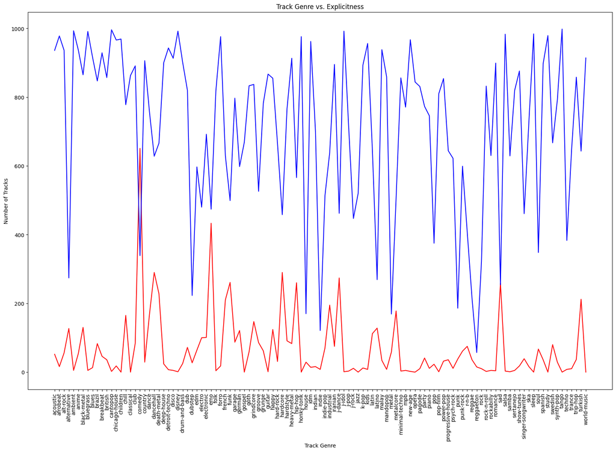

```python
plt.figure(figsize=(20,13))
plt.plot(table.index, table[True], color='red')
plt.plot(table.index, table[False], color='blue')
plt.title("Track Genre vs. Explicitness")
plt.xlabel("Track Genre")
plt.xticks(rotation=90)
plt.ylabel("Number of Tracks")
```

Conduct the chi-squared test and find the p-value.

```python
statistic, p_value, dof, expected_freq = chi2_contingency(table)
print("p_value:", p_value)
print("chi_squared_value:", statistic)
```

```
p_value: 0.0
chi_squared_value: 16827.02770899498
```

Since our p_value is 0.0, it is less than the alpha value of .05, so we reject the null hypothesis. Hence, the genre of the track does have an effect on whether or not it is explicit. A p-value of 0.0 indicates extremely strong evidence against the null hypothesis.

# Insights & Conclusions

Based on our observations, we can safely conclude that:

1. There is no way to predict how popular a song is based on its danceability, since we got an R^2 value of 0.003, which is very close to 0, which means that there is basically no correlation between danceability and popularity.
2. When narrowing the scope of the data to only pop songs, we found out that there is a clear correlation between a song's acousticness and popularity. This is probably because pop is very closely associated with acousticness.

If we conducted further analysis, we would go more in depth for more genres, and find out what genres are closely correlated with what categories, like maybe valence (how positive/negative a song is) with genres like rock, metal, etc. Lastly, we could also look at specific artists that have recently gotten popular, and see the values of their categories and compare them with an unpopular artist to see what the main differences in their music are (within the same song genre). That way, we could see if a popular artist has popular songs just because they are a popular artist, or their songs have something special compared to the artists that are not as popular.